# Aula 08 - Modelos Aditivos Generalizados (GAMs)

Aline Bueno, José Daniel Bastos e Juliana Moureira

2025-10-01

## 1 Introdução

O presente relatório tem como objetivo relacionar a abundância de captura acidental do Tubarão (*Lamna nasus*) com temperatura do mar, presente na base de dados “fisheries”.

Suspeitamos de que é uma variável 0 inflacionada. Verificação de distribuição da variável resposta, além de ver a presença de valores extremos:

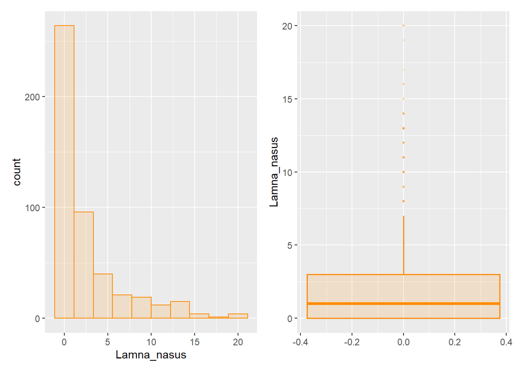

```
##    Min. 1st Qu.  Median    Mean 3rd Qu.    Max.
##    0.00    0.00    1.00    2.62    3.00   20.00
```

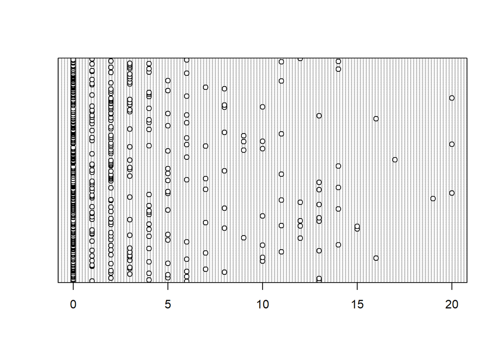

De fato, há uma grande frequência de valores em 0, o que pode ser um indicativo para utilizar modelos zero-inflacionados posteriormente. Dando continuidade, checamos quais variáveis estão correlacionadas.

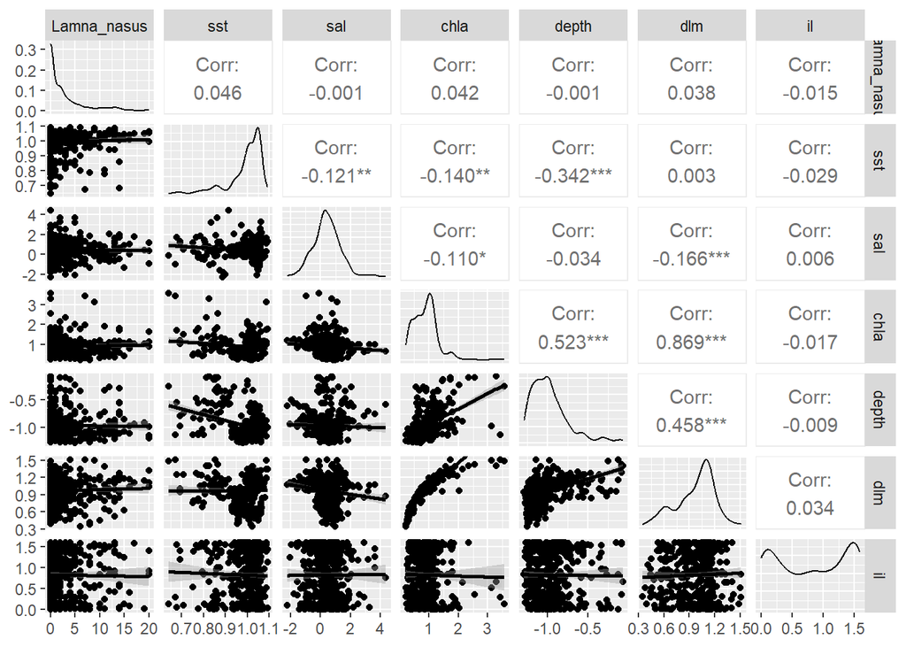

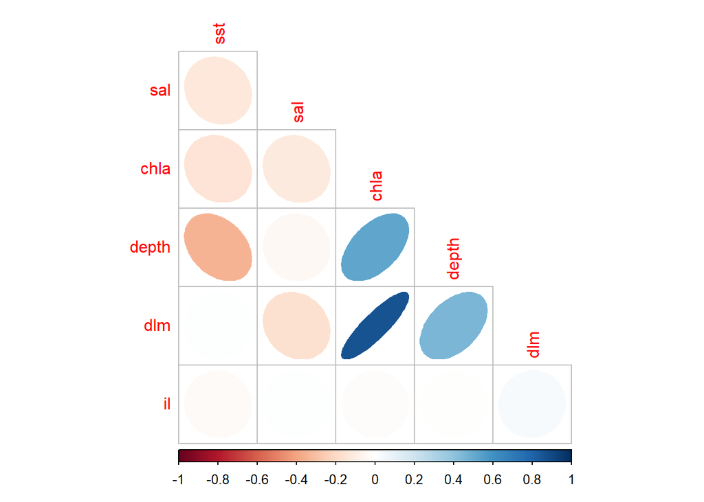

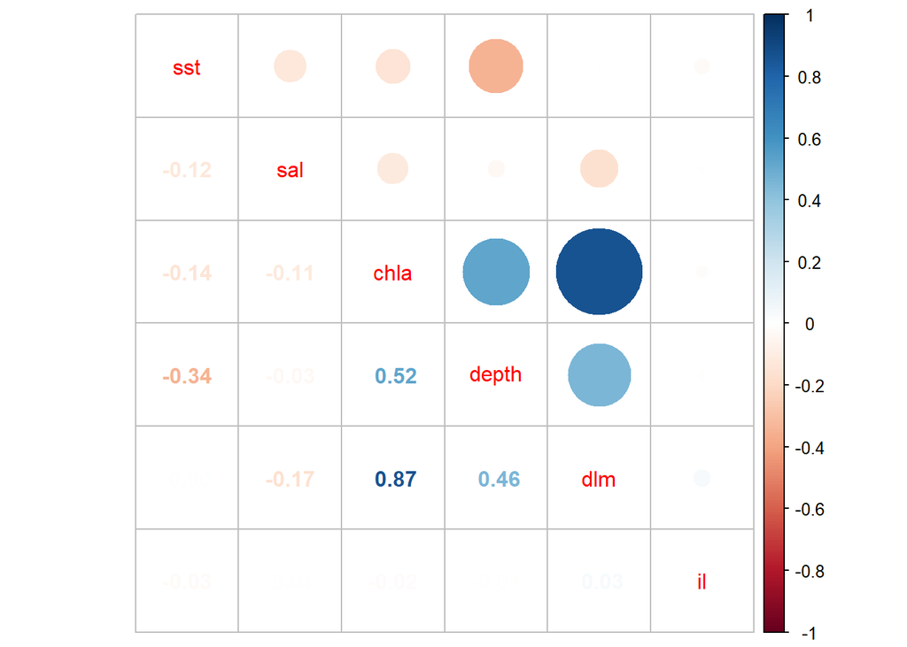

```r
### GAM com dados de contagem
fisheries <- readRDS("C:/Users/José/OneDrive/Área de Trabalho/Disciplinas mestrado/Modelos Lineares Generalizados e Aditivos/Disciplina_GLM_GAM/ECL0072-GLM_GAM-gh-pages/ECL0072-GLM_GAM-gh-pages/Dados/fisheries.rds")
m_gam_pois <- gam(Lamna_nasus ~ s(sst, bs = "cr"),
              data = fisheries,
              family = poisson())

m_gam_BN <- gam(Lamna_nasus ~ s(sst, bs = "cr"),
              data = fisheries,
              family = nb(link="log"))


# 0 inflado
m_gam_tweedie<- gam(Lamna_nasus ~ s(sst, bs = "cr"),
              data = fisheries,
              family = tw(link = "log"))

# Não consegui fazer modelos 0 inflacionados pela função "gam", então farei pelo "gamlss".
library(gamlss)

modelo_zap_gam <- gamlss(
  Lamna_nasus ~ pb(sst),
  sigma.formula = ~ 1,
  family = ZAP(),
  data = fisheries)
```

```
## GAMLSS-RS iteration 1: Global Deviance = 2291.904
## GAMLSS-RS iteration 2: Global Deviance = 2291.904
```

```r
modelo_zanbi_gam <- gamlss(
  Lamna_nasus ~ pb(sst),
  sigma.formula = ~ 1,
  family = ZANBI(),
  data = fisheries)
```

```
## GAMLSS-RS iteration 1: Global Deviance = 1931.916
## GAMLSS-RS iteration 2: Global Deviance = 1929.757
## GAMLSS-RS iteration 3: Global Deviance = 1928.852
## GAMLSS-RS iteration 4: Global Deviance = 1928.631
## GAMLSS-RS iteration 5: Global Deviance = 1928.597
## GAMLSS-RS iteration 6: Global Deviance = 1928.6
## GAMLSS-RS iteration 7: Global Deviance = 1928.605
## GAMLSS-RS iteration 8: Global Deviance = 1928.611
## GAMLSS-RS iteration 9: Global Deviance = 1928.613
## GAMLSS-RS iteration 10: Global Deviance = 1928.615
## GAMLSS-RS iteration 11: Global Deviance = 1928.616
```

```r
modelo_zaga_gam <- gamlss(
  Lamna_nasus ~ pb(sst),
  sigma.formula = ~ 1,
  family = ZAGA(),
  data = fisheries)
```

```
## GAMLSS-RS iteration 1: Global Deviance = 1958.808
## GAMLSS-RS iteration 2: Global Deviance = 1958.822
## GAMLSS-RS iteration 3: Global Deviance = 1958.822
```

```r
AIC(m_gam_pois, m_gam_BN, m_gam_tweedie, modelo_zap_gam, modelo_zanbi_gam, modelo_zaga_gam)
```

```
##                        df      AIC
## m_gam_pois       9.467731 3135.237
## m_gam_BN         3.921600 1945.153
## m_gam_tweedie    5.184382 1968.824
## modelo_zap_gam   6.285282 2304.474
## modelo_zanbi_gam 5.209767 1939.036
## modelo_zaga_gam  5.529293 1969.881
```

```r
# Distribuição ZANBI com melhor AIC
```

O modelo com distribuição ZANBI possui o melhor AIC. Assim, adicionrei outras variáveis.

```r
zanbi_gam2 <- gamlss(
  Lamna_nasus ~ pb(sst) + pb(sal),
  sigma.formula = ~ 1,
  family = ZANBI(),
  data = fisheries)
```

```
## GAMLSS-RS iteration 1: Global Deviance = 1932.056
## GAMLSS-RS iteration 2: Global Deviance = 1929.804
## GAMLSS-RS iteration 3: Global Deviance = 1929.011
## GAMLSS-RS iteration 4: Global Deviance = 1928.822
## GAMLSS-RS iteration 5: Global Deviance = 1928.785
## GAMLSS-RS iteration 6: Global Deviance = 1928.786
```

```r
zanbi_gam3 <- gamlss(
  Lamna_nasus ~ pb(sst) + pb(sal) + pb(chla),
  sigma.formula = ~ 1,
  family = ZANBI(),
  data = fisheries)
```

```
## GAMLSS-RS iteration 1: Global Deviance = 1931.883
## GAMLSS-RS iteration 2: Global Deviance = 1929.609
## GAMLSS-RS iteration 3: Global Deviance = 1928.723
## GAMLSS-RS iteration 4: Global Deviance = 1928.504
## GAMLSS-RS iteration 5: Global Deviance = 1928.469
## GAMLSS-RS iteration 6: Global Deviance = 1928.465
## GAMLSS-RS iteration 7: Global Deviance = 1928.476
## GAMLSS-RS iteration 8: Global Deviance = 1928.476
```

```r
zanbi_gam4 <- gamlss(
  Lamna_nasus ~ pb(sst) + pb(sal) + pb(chla) + pb(il),
  sigma.formula = ~ 1,
  family = ZANBI(),
  data = fisheries)
```

```
## GAMLSS-RS iteration 1: Global Deviance = 1930.566
## GAMLSS-RS iteration 2: Global Deviance = 1928.468
## GAMLSS-RS iteration 3: Global Deviance = 1927.543
## GAMLSS-RS iteration 4: Global Deviance = 1927.373
## GAMLSS-RS iteration 5: Global Deviance = 1927.318
## GAMLSS-RS iteration 6: Global Deviance = 1927.32
## GAMLSS-RS iteration 7: Global Deviance = 1927.32
```

```r
# Padronizando pelo esforço amostral
zanbi_gam_off <- gamlss(
  Lamna_nasus ~ pb(sst) + offset(log(N_anzol)) ,
  sigma.formula = ~ 1,
  family = ZANBI(),
  data = fisheries)
```

```
## GAMLSS-RS iteration 1: Global Deviance = 1937.066
## GAMLSS-RS iteration 2: Global Deviance = 1935.256
## GAMLSS-RS iteration 3: Global Deviance = 1934.613
## GAMLSS-RS iteration 4: Global Deviance = 1934.45
## GAMLSS-RS iteration 5: Global Deviance = 1934.43
## GAMLSS-RS iteration 6: Global Deviance = 1934.446
## GAMLSS-RS iteration 7: Global Deviance = 1934.466
## GAMLSS-RS iteration 8: Global Deviance = 1934.475
## GAMLSS-RS iteration 9: Global Deviance = 1934.482
## GAMLSS-RS iteration 10: Global Deviance = 1934.484
## GAMLSS-RS iteration 11: Global Deviance = 1934.486
## GAMLSS-RS iteration 12: Global Deviance = 1934.487
## GAMLSS-RS iteration 13: Global Deviance = 1934.487
```

```r
# Covariável
zanbi_gam_cov <- gamlss(
  Lamna_nasus ~ pb(sst),
  sigma.formula = ~ Mes,
  family = ZANBI(),
  data = fisheries)
```

```
## GAMLSS-RS iteration 1: Global Deviance = 1906.802
## GAMLSS-RS iteration 2: Global Deviance = 1913.375
## GAMLSS-RS iteration 3: Global Deviance = 1914.868
## GAMLSS-RS iteration 4: Global Deviance = 1911.542
## GAMLSS-RS iteration 5: Global Deviance = 1919.942
## GAMLSS-RS iteration 6: Global Deviance = 1923.12
## GAMLSS-RS iteration 7: Global Deviance = 1926.265
## GAMLSS-RS iteration 8: Global Deviance = 1911.158
## GAMLSS-RS iteration 9: Global Deviance = 757.8723
## GAMLSS-RS iteration 10: Global Deviance = 412.8908
## GAMLSS-RS iteration 11: Global Deviance = 261.9517
## GAMLSS-RS iteration 12: Global Deviance = 164.5677
## GAMLSS-RS iteration 13: Global Deviance = 92.7043
## GAMLSS-RS iteration 14: Global Deviance = 35.7848
## GAMLSS-RS iteration 15: Global Deviance = -11.3039
## GAMLSS-RS iteration 16: Global Deviance = -51.4426
## GAMLSS-RS iteration 17: Global Deviance = -86.4086
## GAMLSS-RS iteration 18: Global Deviance = -117.3755
## GAMLSS-RS iteration 19: Global Deviance = -145.1589
## GAMLSS-RS iteration 20: Global Deviance = -170.3485
```

```r
AIC(modelo_zanbi_gam, zanbi_gam2, zanbi_gam3, zanbi_gam4, zanbi_gam_off, zanbi_gam_cov)
```

```
##                         df       AIC
## zanbi_gam_cov    22.999891 -124.3487
## modelo_zanbi_gam  5.209767 1939.0358
## zanbi_gam2        6.412634 1941.6118
## zanbi_gam3        7.376189 1943.2280
## zanbi_gam4        8.449747 1944.2190
## zanbi_gam_off     5.243967 1944.9754
```

```r
summary(zanbi_gam_cov)
```

```
## Family:  c("ZANBI", "Zero Altered Negative binomial type I")
##
## Call:  gamlss(formula = Lamna_nasus ~ pb(sst), sigma.formula = ~Mes,
##     family = ZANBI(), data = fisheries)
##
## Fitting method: RS()
##
## ------------------------------------------------------------------
## Mu link function:  log
## Mu Coefficients:
##             Estimate Std. Error t value Pr(>|t|)
## (Intercept) -0.72874   18.82896  -0.039    0.969
## pb(sst)      0.01094    0.74330   0.015    0.988
##
## ------------------------------------------------------------------
## Sigma link function:  log
## Sigma Coefficients:
##             Estimate Std. Error t value Pr(>|t|)
## (Intercept)  17.4789     1.9562   8.935   <2e-16 ***
## Mes          -0.9773     0.1099  -8.890   <2e-16 ***
## ---
## Signif. codes:  0 '***' 0.001 '**' 0.01 '*' 0.05 '.' 0.1 ' ' 1
##
## ------------------------------------------------------------------
## Nu link function:  logit
## Nu Coefficients:
##             Estimate Std. Error t value Pr(>|t|)
## (Intercept) -0.18540    0.09206  -2.014   0.0446 *
## ---
## Signif. codes:  0 '***' 0.001 '**' 0.01 '*' 0.05 '.' 0.1 ' ' 1
##
## ------------------------------------------------------------------
## NOTE: Additive smoothing terms exist in the formulas:
##  i) Std. Error for smoothers are for the linear effect only.
## ii) Std. Error for the linear terms maybe are not accurate.
## ------------------------------------------------------------------
## No. of observations in the fit:  476
## Degrees of Freedom for the fit:  22.99989
##       Residual Deg. of Freedom:  453.0001
##                       at cycle:  20
##
## Global Deviance:     -170.3485
##             AIC:     -124.3487
##             SBC:     -28.54452
```

```r
check_model(zanbi_gam_cov)
```

[output not shown]

[output cut: 77 more lines]

[output not shown]

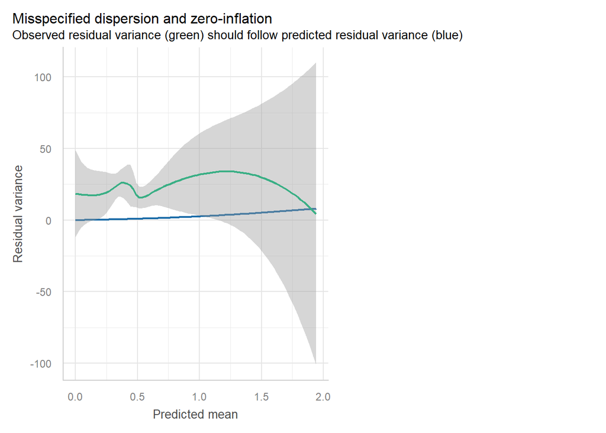

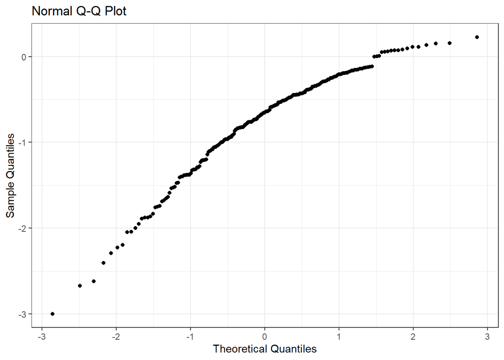

```r
residuos_qr <- resid(zanbi_gam_cov)
qqnorm(residuos_qr)
```

O modelo com o menor valor de AIC foi o que manteve apenas a abundância de captura em função de temperatura da superfície do mar e adicionou-se o mês como uma covariável para explicar a dispersão. Apesar disso, não foi observada relação entre as variáveis, o que também pode ser um indicativo de que outras vaiáveis não capturadas na base de dados podem ser mais relevantes para entender essa relação.

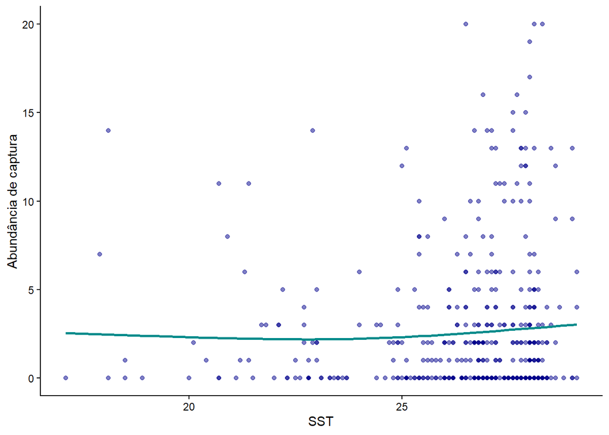